# Risk Factor Analysis

## Outcome Variable

**Outcome Variable:** whz

## Predictor Variables

**Intervention Variable:** mhtcm

**Adjustment Set:**

- arm
- W_mage
- meducyrs
- feducyrs
- single
- impsan
- W_gagebrth
- W_birthwt
- W_birthlen
- vagbrth
- parity
- delta_W_mage
- delta_meducyrs
- delta_feducyrs
- delta_single
- delta_impsan
- delta_W_gagebrth
- delta_W_birthwt
- delta_W_birthlen
- delta_vagbrth
- delta_parity

## Stratifying Variables

The analysis was stratified on these variable(s):

- agecat
- studyid
- country

## Data Summary

| agecat | studyid | country | mhtcm | n_cell | n |
| --- | --- | --- | --- | --- | --- |
| 6 months | ki0047075b-MAL-ED | BANGLADESH | >=155 cm | 24 | 241 |
| 6 months | ki0047075b-MAL-ED | BANGLADESH | <151 cm | 156 | 241 |
| 6 months | ki0047075b-MAL-ED | BANGLADESH | [151-155) cm | 61 | 241 |
| 6 months | ki0047075b-MAL-ED | BRAZIL | >=155 cm | 121 | 209 |
| 6 months | ki0047075b-MAL-ED | BRAZIL | <151 cm | 51 | 209 |
| 6 months | ki0047075b-MAL-ED | BRAZIL | [151-155) cm | 37 | 209 |
| 6 months | ki0047075b-MAL-ED | INDIA | >=155 cm | 55 | 235 |
| 6 months | ki0047075b-MAL-ED | INDIA | <151 cm | 112 | 235 |
| 6 months | ki0047075b-MAL-ED | INDIA | [151-155) cm | 68 | 235 |
| 6 months | ki0047075b-MAL-ED | NEPAL | >=155 cm | 41 | 236 |
| 6 months | ki0047075b-MAL-ED | NEPAL | <151 cm | 132 | 236 |
| 6 months | ki0047075b-MAL-ED | NEPAL | [151-155) cm | 63 | 236 |
| 6 months | ki0047075b-MAL-ED | PERU | >=155 cm | 58 | 272 |
| 6 months | ki0047075b-MAL-ED | PERU | <151 cm | 157 | 272 |
| 6 months | ki0047075b-MAL-ED | PERU | [151-155) cm | 57 | 272 |
| 6 months | ki0047075b-MAL-ED | SOUTH AFRICA | >=155 cm | 187 | 249 |
| 6 months | ki0047075b-MAL-ED | SOUTH AFRICA | <151 cm | 31 | 249 |
| 6 months | ki0047075b-MAL-ED | SOUTH AFRICA | [151-155) cm | 31 | 249 |
| 6 months | ki0047075b-MAL-ED | TANZANIA, UNITED REPUBLIC OF | >=155 cm | 147 | 247 |
| 6 months | ki0047075b-MAL-ED | TANZANIA, UNITED REPUBLIC OF | <151 cm | 48 | 247 |
| 6 months | ki0047075b-MAL-ED | TANZANIA, UNITED REPUBLIC OF | [151-155) cm | 52 | 247 |
| 6 months | ki1000304b-SAS-CompFeed | INDIA | >=155 cm | 509 | 1226 |
| 6 months | ki1000304b-SAS-CompFeed | INDIA | <151 cm | 421 | 1226 |
| 6 months | ki1000304b-SAS-CompFeed | INDIA | [151-155) cm | 296 | 1226 |
| 6 months | ki1000304b-SAS-FoodSuppl | INDIA | >=155 cm | 75 | 379 |
| 6 months | ki1000304b-SAS-FoodSuppl | INDIA | <151 cm | 202 | 379 |
| 6 months | ki1000304b-SAS-FoodSuppl | INDIA | [151-155) cm | 102 | 379 |
| 6 months | ki1017093-NIH-Birth | BANGLADESH | >=155 cm | 96 | 536 |
| 6 months | ki1017093-NIH-Birth | BANGLADESH | <151 cm | 310 | 536 |
| 6 months | ki1017093-NIH-Birth | BANGLADESH | [151-155) cm | 130 | 536 |

[output cut: 93 more lines]

The following strata were considered:

- agecat: 24 months, studyid: ki0047075b-MAL-ED, country: BANGLADESH
- agecat: 24 months, studyid: ki0047075b-MAL-ED, country: BRAZIL
- agecat: 24 months, studyid: ki0047075b-MAL-ED, country: INDIA
- agecat: 24 months, studyid: ki0047075b-MAL-ED, country: NEPAL
- agecat: 24 months, studyid: ki0047075b-MAL-ED, country: PERU
- agecat: 24 months, studyid: ki0047075b-MAL-ED, country: SOUTH AFRICA
- agecat: 24 months, studyid: ki0047075b-MAL-ED, country: TANZANIA, UNITED REPUBLIC OF
- agecat: 24 months, studyid: ki1017093-NIH-Birth, country: BANGLADESH
- agecat: 24 months, studyid: ki1017093b-PROVIDE, country: BANGLADESH
- agecat: 24 months, studyid: ki1017093c-NIH-Crypto, country: BANGLADESH
- agecat: 24 months, studyid: ki1066203-TanzaniaChild2, country: TANZANIA, UNITED REPUBLIC OF
- agecat: 24 months, studyid: ki1101329-Keneba, country: GAMBIA
- agecat: 24 months, studyid: ki1119695-PROBIT, country: BELARUS
- agecat: 24 months, studyid: ki1126311-ZVITAMBO, country: ZIMBABWE
- agecat: 24 months, studyid: ki1135781-COHORTS, country: GUATEMALA
- agecat: 24 months, studyid: ki1135781-COHORTS, country: INDIA
- agecat: 24 months, studyid: ki1135781-COHORTS, country: PHILIPPINES
- agecat: 24 months, studyid: ki1148112-LCNI-5, country: MALAWI
- agecat: 24 months, studyid: kiGH5241-JiVitA-3, country: BANGLADESH
- agecat: 6 months, studyid: ki0047075b-MAL-ED, country: BANGLADESH
- agecat: 6 months, studyid: ki0047075b-MAL-ED, country: BRAZIL
- agecat: 6 months, studyid: ki0047075b-MAL-ED, country: INDIA
- agecat: 6 months, studyid: ki0047075b-MAL-ED, country: NEPAL
- agecat: 6 months, studyid: ki0047075b-MAL-ED, country: PERU
- agecat: 6 months, studyid: ki0047075b-MAL-ED, country: SOUTH AFRICA
- agecat: 6 months, studyid: ki0047075b-MAL-ED, country: TANZANIA, UNITED REPUBLIC OF
- agecat: 6 months, studyid: ki1000304b-SAS-CompFeed, country: INDIA
- agecat: 6 months, studyid: ki1000304b-SAS-FoodSuppl, country: INDIA
- agecat: 6 months, studyid: ki1017093-NIH-Birth, country: BANGLADESH
- agecat: 6 months, studyid: ki1017093b-PROVIDE, country: BANGLADESH
- agecat: 6 months, studyid: ki1017093c-NIH-Crypto, country: BANGLADESH
- agecat: 6 months, studyid: ki1066203-TanzaniaChild2, country: TANZANIA, UNITED REPUBLIC OF
- agecat: 6 months, studyid: ki1101329-Keneba, country: GAMBIA
- agecat: 6 months, studyid: ki1112895-Guatemala BSC, country: GUATEMALA
- agecat: 6 months, studyid: ki1119695-PROBIT, country: BELARUS
- agecat: 6 months, studyid: ki1126311-ZVITAMBO, country: ZIMBABWE
- agecat: 6 months, studyid: ki1135781-COHORTS, country: GUATEMALA
- agecat: 6 months, studyid: ki1135781-COHORTS, country: INDIA
- agecat: 6 months, studyid: ki1135781-COHORTS, country: PHILIPPINES
- agecat: 6 months, studyid: ki1148112-LCNI-5, country: MALAWI
- agecat: 6 months, studyid: kiGH5241-JiVitA-3, country: BANGLADESH

### Dropped Strata

Some strata were dropped due to rare outcomes:

- agecat: 24 months, studyid: ki1066203-TanzaniaChild2, country: TANZANIA, UNITED REPUBLIC OF

## Methods Detail

We’re interested in the causal parameters $E[Y_a]$ for all values of $a \in \mathcal{A}$. These parameters represent the mean outcome if, possibly contrary to fact, we intervened to set all units to have $A=a$. Under the randomization and positivity assumptions, these are identified by the statistical parameters $\psi_a=E_W[E_{Y|A,W}(Y|A=a,W)]$. In addition, we’re interested in the mean of $Y$, $E[Y]$ under no intervention (the observed mean). We will estimate these parameters by using SuperLearner to fit the relevant likelihood factors – $E_{Y|A,W}(Y|A=a,W)$ and $p(A=a|W)$, and then updating our likelihood fit using a joint TMLE.

For unadjusted analyses ($W=\{\}$), initial likelihoods were estimated using Lrnr_glm to estimate the simple $E(Y|A)$ and Lrnr_mean to estimate $p(A)$. For adjusted analyses, a small library containing Lrnr_glmnet, Lrnr_xgboost, and Lrnr_mean was used.

Having estimated these parameters, we will then use the delta method to estimate relative risks and attributable risks relative to a prespecified baseline level of $A$.

# Results Detail

## Results Plots

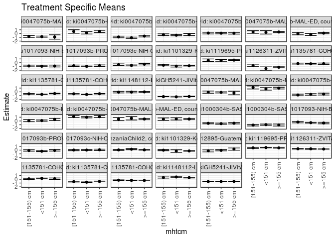

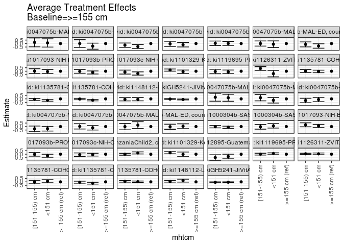

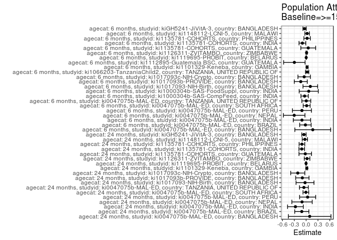

## Results Table

### Parameter: TSM

| agecat | studyid | country | intervention_level | baseline_level | estimate | ci_lower | ci_upper |
| --- | --- | --- | --- | --- | --- | --- | --- |
| 6 months | ki0047075b-MAL-ED | BANGLADESH | >=155 cm | NA | -0.3082934 | -0.7893774 | 0.1727907 |
| 6 months | ki0047075b-MAL-ED | BANGLADESH | <151 cm | NA | -0.1459818 | -0.2933744 | 0.0014109 |
| 6 months | ki0047075b-MAL-ED | BANGLADESH | [151-155) cm | NA | -0.0735438 | -0.3706946 | 0.2236069 |
| 6 months | ki0047075b-MAL-ED | BRAZIL | >=155 cm | NA | 0.9899736 | 0.7632268 | 1.2167204 |
| 6 months | ki0047075b-MAL-ED | BRAZIL | <151 cm | NA | 0.7874980 | 0.4616494 | 1.1133465 |
| 6 months | ki0047075b-MAL-ED | BRAZIL | [151-155) cm | NA | 1.1584654 | 0.7645163 | 1.5524145 |
| 6 months | ki0047075b-MAL-ED | INDIA | >=155 cm | NA | -0.5931334 | -0.8387003 | -0.3475664 |
| 6 months | ki0047075b-MAL-ED | INDIA | <151 cm | NA | -0.6864939 | -0.8843887 | -0.4885992 |
| 6 months | ki0047075b-MAL-ED | INDIA | [151-155) cm | NA | -0.8275999 | -1.0428073 | -0.6123924 |
| 6 months | ki0047075b-MAL-ED | NEPAL | >=155 cm | NA | 0.4133065 | 0.1197338 | 0.7068792 |
| 6 months | ki0047075b-MAL-ED | NEPAL | <151 cm | NA | 0.1052149 | -0.0630041 | 0.2734338 |
| 6 months | ki0047075b-MAL-ED | NEPAL | [151-155) cm | NA | 0.0834560 | -0.1970968 | 0.3640088 |
| 6 months | ki0047075b-MAL-ED | PERU | >=155 cm | NA | 1.1626873 | 0.8893746 | 1.4360000 |
| 6 months | ki0047075b-MAL-ED | PERU | <151 cm | NA | 0.9815655 | 0.8206884 | 1.1424427 |
| 6 months | ki0047075b-MAL-ED | PERU | [151-155) cm | NA | 1.1867614 | 0.9258052 | 1.4477176 |
| 6 months | ki0047075b-MAL-ED | SOUTH AFRICA | >=155 cm | NA | 0.5154268 | 0.3359900 | 0.6948636 |
| 6 months | ki0047075b-MAL-ED | SOUTH AFRICA | <151 cm | NA | 0.7170686 | 0.2594136 | 1.1747236 |
| 6 months | ki0047075b-MAL-ED | SOUTH AFRICA | [151-155) cm | NA | 0.5053355 | 0.0825917 | 0.9280792 |
| 6 months | ki0047075b-MAL-ED | TANZANIA, UNITED REPUBLIC OF | >=155 cm | NA | 0.5125516 | 0.3443811 | 0.6807221 |
| 6 months | ki0047075b-MAL-ED | TANZANIA, UNITED REPUBLIC OF | <151 cm | NA | 0.5545761 | 0.2537216 | 0.8554305 |
| 6 months | ki0047075b-MAL-ED | TANZANIA, UNITED REPUBLIC OF | [151-155) cm | NA | 0.4825463 | 0.1575018 | 0.8075907 |
| 6 months | ki1000304b-SAS-CompFeed | INDIA | >=155 cm | NA | -0.6043667 | -0.7757123 | -0.4330212 |
| 6 months | ki1000304b-SAS-CompFeed | INDIA | <151 cm | NA | -0.7076592 | -0.8579279 | -0.5573906 |
| 6 months | ki1000304b-SAS-CompFeed | INDIA | [151-155) cm | NA | -0.6202400 | -0.7604195 | -0.4800605 |
| 6 months | ki1000304b-SAS-FoodSuppl | INDIA | >=155 cm | NA | -1.0712597 | -1.3401213 | -0.8023981 |
| 6 months | ki1000304b-SAS-FoodSuppl | INDIA | <151 cm | NA | -0.9741356 | -1.1344586 | -0.8138125 |
| 6 months | ki1000304b-SAS-FoodSuppl | INDIA | [151-155) cm | NA | -1.1050386 | -1.3231784 | -0.8868988 |
| 6 months | ki1017093-NIH-Birth | BANGLADESH | >=155 cm | NA | -0.5452971 | -0.7473102 | -0.3432841 |
| 6 months | ki1017093-NIH-Birth | BANGLADESH | <151 cm | NA | -0.4605036 | -0.5731540 | -0.3478531 |
| 6 months | ki1017093-NIH-Birth | BANGLADESH | [151-155) cm | NA | -0.2987809 | -0.5020162 | -0.0955457 |

[output cut: 90 more lines]

### Parameter: E(Y)

| agecat | studyid | country | intervention_level | baseline_level | estimate | ci_lower | ci_upper |
| --- | --- | --- | --- | --- | --- | --- | --- |
| 6 months | ki0047075b-MAL-ED | BANGLADESH | NA | NA | -0.1397960 | -0.2688682 | -0.0107238 |
| 6 months | ki0047075b-MAL-ED | BRAZIL | NA | NA | 0.9717225 | 0.8073791 | 1.1360658 |
| 6 months | ki0047075b-MAL-ED | INDIA | NA | NA | -0.6987943 | -0.8241325 | -0.5734561 |
| 6 months | ki0047075b-MAL-ED | NEPAL | NA | NA | 0.1110452 | -0.0202712 | 0.2423616 |
| 6 months | ki0047075b-MAL-ED | PERU | NA | NA | 1.0563787 | 0.9342938 | 1.1784635 |
| 6 months | ki0047075b-MAL-ED | SOUTH AFRICA | NA | NA | 0.5290428 | 0.3750394 | 0.6830463 |
| 6 months | ki0047075b-MAL-ED | TANZANIA, UNITED REPUBLIC OF | NA | NA | 0.5170513 | 0.3872178 | 0.6468847 |
| 6 months | ki1000304b-SAS-CompFeed | INDIA | NA | NA | -0.6426305 | -0.7702214 | -0.5150396 |
| 6 months | ki1000304b-SAS-FoodSuppl | INDIA | NA | NA | -1.0053826 | -1.1208084 | -0.8899568 |
| 6 months | ki1017093-NIH-Birth | BANGLADESH | NA | NA | -0.4389101 | -0.5279432 | -0.3498771 |
| 6 months | ki1017093b-PROVIDE | BANGLADESH | NA | NA | -0.2079891 | -0.2925599 | -0.1234183 |
| 6 months | ki1017093c-NIH-Crypto | BANGLADESH | NA | NA | 0.0297622 | -0.0491685 | 0.1086930 |
| 6 months | ki1066203-TanzaniaChild2 | TANZANIA, UNITED REPUBLIC OF | NA | NA | 0.0787757 | 0.0256721 | 0.1318793 |
| 6 months | ki1101329-Keneba | GAMBIA | NA | NA | -0.2054148 | -0.2588995 | -0.1519302 |
| 6 months | ki1112895-Guatemala BSC | GUATEMALA | NA | NA | -0.0255916 | -0.1507513 | 0.0995680 |
| 6 months | ki1119695-PROBIT | BELARUS | NA | NA | 0.5827947 | 0.5245418 | 0.6410476 |
| 6 months | ki1126311-ZVITAMBO | ZIMBABWE | NA | NA | 0.2928354 | 0.2648888 | 0.3207820 |
| 6 months | ki1135781-COHORTS | GUATEMALA | NA | NA | 0.1926004 | 0.1207018 | 0.2644990 |
| 6 months | ki1135781-COHORTS | INDIA | NA | NA | -0.6768114 | -0.7301317 | -0.6234912 |
| 6 months | ki1135781-COHORTS | PHILIPPINES | NA | NA | -0.2938433 | -0.3352064 | -0.2524802 |
| 6 months | ki1148112-LCNI-5 | MALAWI | NA | NA | 0.4515431 | 0.3802415 | 0.5228446 |
| 6 months | kiGH5241-JiVitA-3 | BANGLADESH | NA | NA | -0.5932195 | -0.6127714 | -0.5736676 |
| 24 months | ki0047075b-MAL-ED | BANGLADESH | NA | NA | -0.8208255 | -0.9429246 | -0.6987264 |
| 24 months | ki0047075b-MAL-ED | BRAZIL | NA | NA | 0.4466272 | 0.2416144 | 0.6516401 |
| 24 months | ki0047075b-MAL-ED | INDIA | NA | NA | -0.9525664 | -1.0684455 | -0.8366872 |
| 24 months | ki0047075b-MAL-ED | NEPAL | NA | NA | -0.3764474 | -0.4898516 | -0.2630431 |
| 24 months | ki0047075b-MAL-ED | PERU | NA | NA | 0.1199005 | -0.0000331 | 0.2398341 |
| 24 months | ki0047075b-MAL-ED | SOUTH AFRICA | NA | NA | 0.4096154 | 0.2902946 | 0.5289362 |
| 24 months | ki0047075b-MAL-ED | TANZANIA, UNITED REPUBLIC OF | NA | NA | 0.0500935 | -0.0748234 | 0.1750103 |
| 24 months | ki1017093-NIH-Birth | BANGLADESH | NA | NA | -0.9115790 | -1.0095022 | -0.8136559 |
| 24 months | ki1017093b-PROVIDE | BANGLADESH | NA | NA | -0.8864991 | -0.9695215 | -0.8034768 |
| 24 months | ki1017093c-NIH-Crypto | BANGLADESH | NA | NA | -0.6103502 | -0.7050157 | -0.5156847 |
| 24 months | ki1101329-Keneba | GAMBIA | NA | NA | -0.8101717 | -0.8592463 | -0.7610970 |
| 24 months | ki1119695-PROBIT | BELARUS | NA | NA | 0.6869754 | 0.5725638 | 0.8013869 |
| 24 months | ki1126311-ZVITAMBO | ZIMBABWE | NA | NA | -1.1803611 | -1.2905182 | -1.0702040 |
| 24 months | ki1135781-COHORTS | GUATEMALA | NA | NA | -0.2844036 | -0.3405555 | -0.2282517 |
| 24 months | ki1135781-COHORTS | INDIA | NA | NA | -0.5719523 | -0.6185009 | -0.5254037 |
| 24 months | ki1135781-COHORTS | PHILIPPINES | NA | NA | -0.6099592 | -0.6467541 | -0.5731643 |
| 24 months | ki1148112-LCNI-5 | MALAWI | NA | NA | -0.0469519 | -0.1290932 | 0.0351895 |
| 24 months | kiGH5241-JiVitA-3 | BANGLADESH | NA | NA | -1.2970642 | -1.3203662 | -1.2737621 |

### Parameter: ATE

| agecat | studyid | country | intervention_level | baseline_level | estimate | ci_lower | ci_upper |
| --- | --- | --- | --- | --- | --- | --- | --- |
| 6 months | ki0047075b-MAL-ED | BANGLADESH | >=155 cm | >=155 cm | 0.0000000 | 0.0000000 | 0.0000000 |
| 6 months | ki0047075b-MAL-ED | BANGLADESH | <151 cm | >=155 cm | 0.1623116 | -0.3406782 | 0.6653014 |
| 6 months | ki0047075b-MAL-ED | BANGLADESH | [151-155) cm | >=155 cm | 0.2347495 | -0.3303139 | 0.7998130 |
| 6 months | ki0047075b-MAL-ED | BRAZIL | >=155 cm | >=155 cm | 0.0000000 | 0.0000000 | 0.0000000 |
| 6 months | ki0047075b-MAL-ED | BRAZIL | <151 cm | >=155 cm | -0.2024757 | -0.6000459 | 0.1950946 |
| 6 months | ki0047075b-MAL-ED | BRAZIL | [151-155) cm | >=155 cm | 0.1684918 | -0.2855781 | 0.6225616 |
| 6 months | ki0047075b-MAL-ED | INDIA | >=155 cm | >=155 cm | 0.0000000 | 0.0000000 | 0.0000000 |
| 6 months | ki0047075b-MAL-ED | INDIA | <151 cm | >=155 cm | -0.0933606 | -0.4094678 | 0.2227467 |
| 6 months | ki0047075b-MAL-ED | INDIA | [151-155) cm | >=155 cm | -0.2344665 | -0.5613842 | 0.0924512 |
| 6 months | ki0047075b-MAL-ED | NEPAL | >=155 cm | >=155 cm | 0.0000000 | 0.0000000 | 0.0000000 |
| 6 months | ki0047075b-MAL-ED | NEPAL | <151 cm | >=155 cm | -0.3080917 | -0.6460016 | 0.0298182 |
| 6 months | ki0047075b-MAL-ED | NEPAL | [151-155) cm | >=155 cm | -0.3298505 | -0.7348178 | 0.0751168 |
| 6 months | ki0047075b-MAL-ED | PERU | >=155 cm | >=155 cm | 0.0000000 | 0.0000000 | 0.0000000 |
| 6 months | ki0047075b-MAL-ED | PERU | <151 cm | >=155 cm | -0.1811217 | -0.4980301 | 0.1357866 |
| 6 months | ki0047075b-MAL-ED | PERU | [151-155) cm | >=155 cm | 0.0240741 | -0.3538891 | 0.4020374 |
| 6 months | ki0047075b-MAL-ED | SOUTH AFRICA | >=155 cm | >=155 cm | 0.0000000 | 0.0000000 | 0.0000000 |
| 6 months | ki0047075b-MAL-ED | SOUTH AFRICA | <151 cm | >=155 cm | 0.2016418 | -0.2905143 | 0.6937978 |
| 6 months | ki0047075b-MAL-ED | SOUTH AFRICA | [151-155) cm | >=155 cm | -0.0100914 | -0.4700141 | 0.4498313 |
| 6 months | ki0047075b-MAL-ED | TANZANIA, UNITED REPUBLIC OF | >=155 cm | >=155 cm | 0.0000000 | 0.0000000 | 0.0000000 |
| 6 months | ki0047075b-MAL-ED | TANZANIA, UNITED REPUBLIC OF | <151 cm | >=155 cm | 0.0420245 | -0.3066791 | 0.3907281 |
| 6 months | ki0047075b-MAL-ED | TANZANIA, UNITED REPUBLIC OF | [151-155) cm | >=155 cm | -0.0300053 | -0.3980269 | 0.3380162 |
| 6 months | ki1000304b-SAS-CompFeed | INDIA | >=155 cm | >=155 cm | 0.0000000 | 0.0000000 | 0.0000000 |
| 6 months | ki1000304b-SAS-CompFeed | INDIA | <151 cm | >=155 cm | -0.1032925 | -0.2616605 | 0.0550755 |
| 6 months | ki1000304b-SAS-CompFeed | INDIA | [151-155) cm | >=155 cm | -0.0158732 | -0.1888789 | 0.1571324 |
| 6 months | ki1000304b-SAS-FoodSuppl | INDIA | >=155 cm | >=155 cm | 0.0000000 | 0.0000000 | 0.0000000 |
| 6 months | ki1000304b-SAS-FoodSuppl | INDIA | <151 cm | >=155 cm | 0.0971241 | -0.2172593 | 0.4115076 |
| 6 months | ki1000304b-SAS-FoodSuppl | INDIA | [151-155) cm | >=155 cm | -0.0337789 | -0.3787123 | 0.3111546 |
| 6 months | ki1017093-NIH-Birth | BANGLADESH | >=155 cm | >=155 cm | 0.0000000 | 0.0000000 | 0.0000000 |
| 6 months | ki1017093-NIH-Birth | BANGLADESH | <151 cm | >=155 cm | 0.0847936 | -0.1466099 | 0.3161971 |
| 6 months | ki1017093-NIH-Birth | BANGLADESH | [151-155) cm | >=155 cm | 0.2465162 | -0.0404858 | 0.5335183 |

[output cut: 90 more lines]

### Parameter: PAR

| agecat | studyid | country | intervention_level | baseline_level | estimate | ci_lower | ci_upper |
| --- | --- | --- | --- | --- | --- | --- | --- |
| 6 months | ki0047075b-MAL-ED | BANGLADESH | >=155 cm | NA | 0.1684974 | -0.2856579 | 0.6226526 |
| 6 months | ki0047075b-MAL-ED | BRAZIL | >=155 cm | NA | -0.0182511 | -0.1640137 | 0.1275115 |
| 6 months | ki0047075b-MAL-ED | INDIA | >=155 cm | NA | -0.1056610 | -0.3257502 | 0.1144283 |
| 6 months | ki0047075b-MAL-ED | NEPAL | >=155 cm | NA | -0.3022613 | -0.5745194 | -0.0300033 |
| 6 months | ki0047075b-MAL-ED | PERU | >=155 cm | NA | -0.1063086 | -0.3469819 | 0.1343647 |
| 6 months | ki0047075b-MAL-ED | SOUTH AFRICA | >=155 cm | NA | 0.0136160 | -0.0745979 | 0.1018299 |
| 6 months | ki0047075b-MAL-ED | TANZANIA, UNITED REPUBLIC OF | >=155 cm | NA | 0.0044997 | -0.1083264 | 0.1173257 |
| 6 months | ki1000304b-SAS-CompFeed | INDIA | >=155 cm | NA | -0.0382638 | -0.1311469 | 0.0546194 |
| 6 months | ki1000304b-SAS-FoodSuppl | INDIA | >=155 cm | NA | 0.0658771 | -0.1763847 | 0.3081388 |
| 6 months | ki1017093-NIH-Birth | BANGLADESH | >=155 cm | NA | 0.1063870 | -0.0791394 | 0.2919134 |
| 6 months | ki1017093b-PROVIDE | BANGLADESH | >=155 cm | NA | -0.1357599 | -0.3005441 | 0.0290244 |
| 6 months | ki1017093c-NIH-Crypto | BANGLADESH | >=155 cm | NA | -0.0490859 | -0.2072431 | 0.1090713 |
| 6 months | ki1066203-TanzaniaChild2 | TANZANIA, UNITED REPUBLIC OF | >=155 cm | NA | 0.0260622 | -0.0157256 | 0.0678500 |
| 6 months | ki1101329-Keneba | GAMBIA | >=155 cm | NA | 0.0250122 | 0.0010012 | 0.0490232 |
| 6 months | ki1112895-Guatemala BSC | GUATEMALA | >=155 cm | NA | -0.2984077 | -0.5705890 | -0.0262263 |
| 6 months | ki1119695-PROBIT | BELARUS | >=155 cm | NA | 0.0017444 | -0.0026217 | 0.0061105 |
| 6 months | ki1126311-ZVITAMBO | ZIMBABWE | >=155 cm | NA | 0.0117319 | -0.0027162 | 0.0261800 |
| 6 months | ki1135781-COHORTS | GUATEMALA | >=155 cm | NA | 0.0539051 | -0.1339112 | 0.2417215 |
| 6 months | ki1135781-COHORTS | INDIA | >=155 cm | NA | -0.0947544 | -0.1799304 | -0.0095785 |
| 6 months | ki1135781-COHORTS | PHILIPPINES | >=155 cm | NA | 0.0251206 | -0.0565935 | 0.1068347 |
| 6 months | ki1148112-LCNI-5 | MALAWI | >=155 cm | NA | 0.0261741 | -0.0319360 | 0.0842841 |
| 6 months | kiGH5241-JiVitA-3 | BANGLADESH | >=155 cm | NA | -0.0393010 | -0.0807137 | 0.0021118 |
| 24 months | ki0047075b-MAL-ED | BANGLADESH | >=155 cm | NA | 0.0899685 | -0.4498984 | 0.6298353 |
| 24 months | ki0047075b-MAL-ED | BRAZIL | >=155 cm | NA | -0.1101028 | -0.2892645 | 0.0690589 |
| 24 months | ki0047075b-MAL-ED | INDIA | >=155 cm | NA | -0.2713999 | -0.4712849 | -0.0715148 |
| 24 months | ki0047075b-MAL-ED | NEPAL | >=155 cm | NA | -0.1038557 | -0.3617385 | 0.1540270 |
| 24 months | ki0047075b-MAL-ED | PERU | >=155 cm | NA | 0.0383040 | -0.1657261 | 0.2423342 |
| 24 months | ki0047075b-MAL-ED | SOUTH AFRICA | >=155 cm | NA | -0.0066048 | -0.0789156 | 0.0657061 |
| 24 months | ki0047075b-MAL-ED | TANZANIA, UNITED REPUBLIC OF | >=155 cm | NA | -0.0567270 | -0.1682697 | 0.0548156 |
| 24 months | ki1017093-NIH-Birth | BANGLADESH | >=155 cm | NA | -0.0282536 | -0.2556088 | 0.1991016 |
| 24 months | ki1017093b-PROVIDE | BANGLADESH | >=155 cm | NA | -0.0958305 | -0.2649713 | 0.0733102 |
| 24 months | ki1017093c-NIH-Crypto | BANGLADESH | >=155 cm | NA | -0.2124939 | -0.3915844 | -0.0334034 |
| 24 months | ki1101329-Keneba | GAMBIA | >=155 cm | NA | 0.0170682 | -0.0047183 | 0.0388547 |
| 24 months | ki1119695-PROBIT | BELARUS | >=155 cm | NA | -0.0016741 | -0.0114128 | 0.0080646 |
| 24 months | ki1126311-ZVITAMBO | ZIMBABWE | >=155 cm | NA | 0.0236236 | -0.0472392 | 0.0944865 |
| 24 months | ki1135781-COHORTS | GUATEMALA | >=155 cm | NA | -0.0219841 | -0.1811901 | 0.1372218 |
| 24 months | ki1135781-COHORTS | INDIA | >=155 cm | NA | -0.1111383 | -0.1825600 | -0.0397165 |
| 24 months | ki1135781-COHORTS | PHILIPPINES | >=155 cm | NA | -0.1064595 | -0.1778943 | -0.0350247 |
| 24 months | ki1148112-LCNI-5 | MALAWI | >=155 cm | NA | -0.0318387 | -0.0994940 | 0.0358166 |
| 24 months | kiGH5241-JiVitA-3 | BANGLADESH | >=155 cm | NA | -0.0553002 | -0.1101067 | -0.0004936 |